# SEM analysis - project Greenwashing

Author

Cappella MT -

Published

Analysis for paper2

# Setup

**Set Working Directory**

```r
setwd("/Users/mariateresa/Downloads/SEM_code_GW_html")
#save.image(file="Sam-Log&Management.RData")
load(file="/Users/mariateresa/Downloads/SEM_code_GW_html/Workspace-SEM.RData")
source("cfanew.R")
```

**Required Packages**

```r
library(readr)
library(here)
library(dplyr)  # to recode nominal variables
library(corrplot)
library(cSEM)
library(lavaan)
library(psych)
library(semPlot)
library(semTools)
library(sjPlot)
library(pander)
library("report") # the report() function allows to report test results in a more readable way—but it also interprets results for you.
library(stargazer)
library(graph4lg) # to order the column of a data set
library(gdata) # per obtain a full matrix from a low-triangular
library(table1) # for categorical data descriptive
library(fastDummies) # for creating dummy var
#library(purrr) # to replace for loops with walk()
library(gt) # for creating tables
library(htmltools) # htmltools::tagList() to obatin tables in collapsible panels
library(readxl)
```

# Data

**Import Data (Simulate data)**

```r
dati<-read_xlsx("questionnaire_dataset_simulation.xlsx")
head(dati)
dim(dati)
complete.cases(dati) # check if there are missing data
summary(dati)
#| label: Data dimensions
n <- nrow(dati)
p <- ncol(dati)
```

**Note**

Simulate data

##Variables selection

```r
rm(n,p) # from previous chunk
# select the variables to be used in the SEM

selected.dati <- dati[, c(
  # Demografiche
   "gender", "age", "area", "family_size", "education", "job", "work_environment", "INC_1", "INC_2", "INC_3",
  paste0("GW_1_", 1:5),
  paste0("GW_2_", 1:5),
  paste0("GPI_1_", 1:3),
  paste0("GPI_2_", 1:3),
  paste0("INV_", 1:3),
  paste0("SKP_", 1:3),
  paste0("ENVKNW_", 1:6)
)]
dim(selected.dati)
```

**Manifest variables and latent constructs**

```r
#Manifest variables and latent for Coffee 1
MV_lists_1 <- list(
  GW_1 = paste0("GW_1_", 1:5),
  GPI_1 = paste0("GPI_1_", 1:3),
  ENVINV = paste0("INV_", 1:3),
  GCS = paste0("SKP_", 1:3),
  ENVK = paste0("ENVKNW_", 1:6)
)

#Manifest variables and latent for Coffee 2
MV_lists_2 <- list(
  GW_2 = paste0("GW_2_", 1:5),
  GPI_2 = paste0("GPI_2_", 1:3),
  INV = paste0("INV_", 1:3),  # invariato, livello between
  SKP = paste0("SKP_", 1:3),  # invariato
  ENVKNW = paste0("ENVKNW_", 1:6)  # invariato
)

#measurement model - level 1 (within)
cfasyntaxlist_1 <- list(
  # Coffee 1
  'GW_1 =~ GW_1_1 + GW_1_2 + GW_1_3 + GW_1_4 + GW_1_5',
  'GPI_1 =~ GPI_1_1 + GPI_1_2 + GPI_1_3',
  'INV =~ INV_1 + INV_2 + INV_3',
  'SKP =~ SKP_1 + SKP_2 + SKP_3',
  'ENVKNW =~ ENVKNW_1 + ENVKNW_2 + ENVKNW_3 + ENVKNW_4 + ENVKNW_5 + ENVKNW_6'
)

#general variables - level 2 (between)

cfasyntaxlist_2 <- list(
  'GW_2 =~ GW_2_1 + GW_2_2 + GW_2_3 + GW_2_4 + GW_2_5',
  'GPI_2 =~ GPI_2_1 + GPI_2_2 + GPI_2_3',
  'INV =~ INV_1 + INV_2 + INV_3',
  'SKP =~ SKP_1 + SKP_2 + SKP_3',
  'ENVKNW =~ ENVKNW_1 + ENVKNW_2 + ENVKNW_3 + ENVKNW_4 + ENVKNW_5 + ENVKNW_6'
)
```

# Uni and Bivariate Stat

**Descriptives**

```r
# for quant var
#sem_descriptives(selected.dati[,-c(1:7)]) # remove demo var
library(psych)
psych::describe(selected.dati[, 8:ncol(selected.dati)])
```

|  | vars | n | mean | sd | median | trimmed | mad | min | max | range | skew | kurtosis | se |
| --- | --- | --- | --- | --- | --- | --- | --- | --- | --- | --- | --- | --- | --- |
| INC_1 | 1 | 1000 | 4.059 | 2.002381 | 4 | 4.07375 | 2.9652 | 1 | 7 | 6 | -0.0398801956 | -1.250041 | 0.06332084 |
| INC_2 | 2 | 1000 | 3.920 | 2.026748 | 4 | 3.90000 | 2.9652 | 1 | 7 | 6 | 0.0719946210 | -1.281531 | 0.06409140 |
| INC_3 | 3 | 1000 | 3.984 | 1.956418 | 4 | 3.98000 | 2.9652 | 1 | 7 | 6 | 0.0111565338 | -1.190927 | 0.06186737 |
| GW_1_1 | 4 | 1000 | 4.025 | 1.984518 | 4 | 4.03125 | 2.9652 | 1 | 7 | 6 | -0.0744779203 | -1.227086 | 0.06275598 |
| GW_1_2 | 5 | 1000 | 4.022 | 1.989843 | 4 | 4.02750 | 2.9652 | 1 | 7 | 6 | -0.0410059114 | -1.214190 | 0.06292436 |
| GW_1_3 | 6 | 1000 | 4.020 | 1.976742 | 4 | 4.02500 | 2.9652 | 1 | 7 | 6 | 0.0173192258 | -1.233505 | 0.06251006 |
| GW_1_4 | 7 | 1000 | 4.002 | 1.995991 | 4 | 4.00250 | 2.9652 | 1 | 7 | 6 | -0.0140694356 | -1.234839 | 0.06311878 |
| GW_1_5 | 8 | 1000 | 4.034 | 2.023101 | 4 | 4.04250 | 2.9652 | 1 | 7 | 6 | 0.0109775305 | -1.280501 | 0.06397607 |
| GW_2_1 | 9 | 1000 | 4.007 | 2.022137 | 4 | 4.00875 | 2.9652 | 1 | 7 | 6 | 0.0071615119 | -1.275256 | 0.06394560 |
| GW_2_2 | 10 | 1000 | 4.044 | 1.992494 | 4 | 4.05500 | 2.9652 | 1 | 7 | 6 | -0.0105692505 | -1.259479 | 0.06300821 |

[output cut: 21 more lines]

```r
# for categorical var
table1::table1(~ ., data = selected.dati[, 1:7],
               na.rm = TRUE, digits = 1, format.number = TRUE)
```

|  | Overall (N=1000) |
| --- | --- |
| gender |  |
| F | 337 (33.7%) |
| M | 312 (31.2%) |
| NR | 351 (35.1%) |
| age |  |
| Mean (SD) | 50 (20) |
| Median [Min, Max] | 50 [20, 80] |
| area |  |
| Center | 254 (25.4%) |
| Islands | 270 (27.0%) |
| North | 222 (22.2%) |
| South | 254 (25.4%) |
| family_size |  |
| Mean (SD) | 3 (2) |
| Median [Min, Max] | 3 [1, 6] |
| education |  |
| Degree | 206 (20.6%) |
| Elementary | 175 (17.5%) |
| HighSchool | 221 (22.1%) |
| Middle | 200 (20.0%) |
| Postgraduate | 198 (19.8%) |
| job |  |
| Craftsman | 81 (8.1%) |
| Employee | 71 (7.1%) |
| Entrepreneur | 68 (6.8%) |
| Farmer | 68 (6.8%) |
| Freelancer | 68 (6.8%) |
| Homemaker | 80 (8.0%) |
| Manager | 75 (7.5%) |
| Other | 68 (6.8%) |
| Retailer | 60 (6.0%) |
| Retired | 66 (6.6%) |
| Student | 69 (6.9%) |
| Teacher | 84 (8.4%) |
| Unemployed | 79 (7.9%) |
| Worker | 63 (6.3%) |
| work_environment |  |
| Directly_related | 196 (19.6%) |
| Don't_know | 221 (22.1%) |
| Indirectly_related | 195 (19.5%) |
| Not_related | 184 (18.4%) |
| Unemployed | 204 (20.4%) |

**Correlation Matrix**

```r
tab_corr(selected.dati[,-c(1:10)], na.deletion = "pairwise", digits = 2, triangle = "lower")
```

|  | GW_1_1 | GW_1_2 | GW_1_3 | GW_1_4 | GW_1_5 | GW_2_1 | GW_2_2 | GW_2_3 | GW_2_4 | GW_2_5 | GPI_1_1 | GPI_1_2 | GPI_1_3 | GPI_2_1 | GPI_2_2 | GPI_2_3 | INV_1 | INV_2 | INV_3 | SKP_1 | SKP_2 | SKP_3 | ENVKNW_1 | ENVKNW_2 | ENVKNW_3 | ENVKNW_4 | ENVKNW_5 | ENVKNW_6 |
| --- | --- | --- | --- | --- | --- | --- | --- | --- | --- | --- | --- | --- | --- | --- | --- | --- | --- | --- | --- | --- | --- | --- | --- | --- | --- | --- | --- | --- |
| GW_1_1 |  |  |  |  |  |  |  |  |  |  |  |  |  |  |  |  |  |  |  |  |  |  |  |  |  |  |  |  |
| GW_1_2 | 0.04 |  |  |  |  |  |  |  |  |  |  |  |  |  |  |  |  |  |  |  |  |  |  |  |  |  |  |  |
| GW_1_3 | -0.03 | -0.03 |  |  |  |  |  |  |  |  |  |  |  |  |  |  |  |  |  |  |  |  |  |  |  |  |  |  |
| GW_1_4 | 0.00 | 0.00 | 0.04 |  |  |  |  |  |  |  |  |  |  |  |  |  |  |  |  |  |  |  |  |  |  |  |  |  |
| GW_1_5 | -0.03 | 0.02 | -0.02 | 0.05 |  |  |  |  |  |  |  |  |  |  |  |  |  |  |  |  |  |  |  |  |  |  |  |  |
| GW_2_1 | -0.05 | -0.03 | -0.07* | -0.00 | -0.03 |  |  |  |  |  |  |  |  |  |  |  |  |  |  |  |  |  |  |  |  |  |  |  |
| GW_2_2 | -0.01 | 0.00 | 0.00 | 0.01 | -0.00 | 0.00 |  |  |  |  |  |  |  |  |  |  |  |  |  |  |  |  |  |  |  |  |  |  |
| GW_2_3 | -0.02 | 0.07* | -0.04 | 0.02 | -0.03 | -0.02 | -0.07* |  |  |  |  |  |  |  |  |  |  |  |  |  |  |  |  |  |  |  |  |  |
| GW_2_4 | 0.00 | 0.00 | 0.07* | 0.03 | 0.04 | -0.03 | -0.01 | -0.02 |  |  |  |  |  |  |  |  |  |  |  |  |  |  |  |  |  |  |  |  |
| GW_2_5 | 0.02 | -0.01 | -0.02 | -0.04 | -0.01 | -0.02 | -0.02 | 0.04 | -0.02 |  |  |  |  |  |  |  |  |  |  |  |  |  |  |  |  |  |  |  |
| GPI_1_1 | -0.05 | 0.05 | -0.05 | -0.01 | -0.07* | 0.03 | -0.01 | 0.01 | 0.02 | -0.01 |  |  |  |  |  |  |  |  |  |  |  |  |  |  |  |  |  |  |
| GPI_1_2 | -0.03 | 0.02 | 0.01 | -0.03 | 0.00 | 0.01 | 0.03 | -0.00 | -0.03 | -0.03 | 0.03 |  |  |  |  |  |  |  |  |  |  |  |  |  |  |  |  |  |
| GPI_1_3 | 0.03 | -0.04 | -0.05 | 0.01 | 0.05 | -0.01 | -0.02 | 0.01 | -0.01 | -0.04 | -0.01 | 0.01 |  |  |  |  |  |  |  |  |  |  |  |  |  |  |  |  |
| GPI_2_1 | -0.02 | -0.06* | -0.01 | 0.00 | 0.02 | -0.01 | 0.01 | 0.04 | -0.03 | 0.01 | -0.03 | -0.01 | -0.00 |  |  |  |  |  |  |  |  |  |  |  |  |  |  |  |
| GPI_2_2 | 0.01 | -0.03 | -0.01 | -0.00 | -0.01 | 0.02 | -0.07* | 0.02 | -0.08* | -0.04 | 0.01 | 0.02 | -0.02 | -0.02 |  |  |  |  |  |  |  |  |  |  |  |  |  |  |
| GPI_2_3 | 0.03 | 0.05 | 0.02 | 0.03 | -0.01 | -0.00 | 0.04 | -0.04 | 0.01 | -0.03 | 0.01 | 0.00 | 0.01 | -0.09** | -0.00 |  |  |  |  |  |  |  |  |  |  |  |  |  |
| INV_1 | 0.02 | 0.03 | -0.05 | 0.00 | -0.01 | 0.01 | 0.01 | -0.05 | -0.03 | -0.01 | -0.02 | -0.06* | -0.03 | -0.01 | -0.05 | -0.03 |  |  |  |  |  |  |  |  |  |  |  |  |
| INV_2 | 0.05 | -0.01 | -0.04 | -0.02 | -0.04 | -0.04 | -0.04 | 0.04 | 0.04 | 0.01 | 0.01 | 0.00 | 0.01 | -0.00 | 0.03 | 0.02 | 0.06 |  |  |  |  |  |  |  |  |  |  |  |
| INV_3 | -0.02 | -0.01 | 0.05 | -0.01 | -0.01 | 0.03 | 0.01 | -0.00 | -0.04 | 0.04 | 0.02 | 0.01 | 0.04 | -0.03 | 0.00 | 0.02 | -0.00 | 0.01 |  |  |  |  |  |  |  |  |  |  |
| SKP_1 | -0.01 | 0.01 | -0.02 | 0.04 | 0.06 | 0.01 | 0.03 | 0.02 | 0.05 | 0.02 | -0.01 | -0.01 | 0.07* | 0.01 | -0.04 | 0.00 | -0.01 | 0.00 | -0.04 |  |  |  |  |  |  |  |  |  |
| SKP_2 | -0.02 | -0.05 | -0.01 | -0.02 | -0.06 | -0.06 | 0.02 | -0.02 | -0.01 | 0.05 | -0.01 | 0.06 | 0.03 | 0.07* | -0.01 | 0.01 | -0.04 | -0.04 | -0.02 | 0.03 |  |  |  |  |  |  |  |  |
| SKP_3 | -0.02 | 0.00 | 0.03 | 0.02 | 0.02 | -0.00 | -0.01 | 0.06 | 0.03 | -0.03 | 0.01 | 0.02 | -0.02 | 0.02 | -0.02 | -0.01 | -0.03 | -0.01 | -0.03 | -0.02 | -0.04 |  |  |  |  |  |  |  |
| ENVKNW_1 | -0.03 | -0.04 | 0.02 | -0.09** | -0.02 | -0.02 | 0.05 | 0.01 | -0.05 | 0.04 | 0.00 | 0.05 | 0.01 | -0.01 | -0.04 | -0.01 | 0.02 | -0.04 | -0.00 | 0.01 | 0.01 | 0.02 |  |  |  |  |  |  |
| ENVKNW_2 | -0.05 | -0.01 | 0.01 | 0.01 | -0.00 | -0.01 | 0.00 | 0.04 | 0.01 | -0.01 | -0.02 | -0.01 | -0.01 | -0.02 | 0.00 | -0.00 | 0.01 | 0.03 | 0.01 | -0.04 | -0.02 | -0.05 | 0.03 |  |  |  |  |  |
| ENVKNW_3 | -0.01 | 0.05 | 0.01 | -0.06 | 0.01 | -0.04 | 0.01 | 0.01 | 0.00 | 0.01 | 0.03 | -0.06 | 0.02 | 0.01 | -0.06 | 0.04 | 0.01 | 0.02 | -0.01 | 0.04 | -0.02 | -0.02 | 0.03 | 0.01 |  |  |  |  |
| ENVKNW_4 | 0.05 | 0.03 | 0.01 | -0.02 | -0.01 | 0.03 | 0.00 | -0.05 | 0.02 | 0.03 | 0.02 | -0.00 | 0.01 | 0.01 | -0.02 | 0.00 | -0.05 | 0.01 | 0.04 | -0.03 | -0.01 | 0.03 | -0.03 | 0.03 | -0.02 |  |  |  |
| ENVKNW_5 | -0.04 | 0.02 | 0.03 | 0.02 | 0.02 | 0.01 | 0.03 | 0.04 | -0.01 | -0.02 | -0.06 | -0.01 | 0.01 | -0.03 | 0.04 | 0.02 | -0.02 | -0.06 | 0.01 | -0.03 | -0.01 | 0.01 | 0.04 | -0.06 | 0.03 | 0.02 |  |  |
| ENVKNW_6 | -0.02 | 0.06 | -0.01 | -0.04 | -0.07* | 0.05 | -0.02 | 0.04 | -0.07* | -0.01 | -0.00 | 0.06 | 0.02 | 0.08* | 0.01 | -0.00 | 0.03 | -0.04 | 0.04 | -0.03 | -0.02 | 0.02 | 0.02 | -0.04 | 0.02 | 0.01 | 0.03 |  |
| Computed correlation used pearson-method with pairwise-deletion. |  |  |  |  |  |  |  |  |  |  |  |  |  |  |  |  |  |  |  |  |  |  |  |  |  |  |  |  |

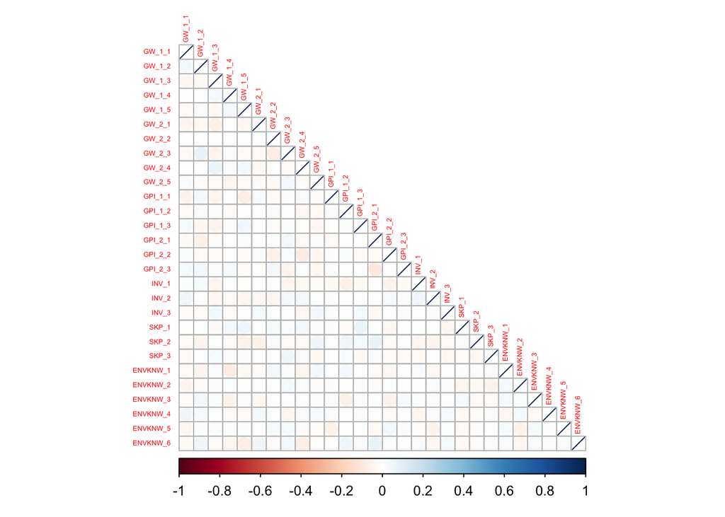

```r
corrplot(cor(selected.dati[,-c(1:10)]),method="ellips",type="lower",tl.cex=0.4)
```

**Skew and Mardia tests**

```
     b1d      chi       df        p
  20.857 3476.113 4060.000    1.000
```

**Warning**

Random sample - Fake normality

# CFAs results

**Correlation structure for each scale**

```r
#RUN CFA and reliability analysis for each scale
res.CFA <- CFA_rel_analysisV2(MV_lists = MV_lists_1, cfa.models = cfasyntaxlist_1, dati = selected.dati, estimator.used = "MLMV")
#DATI TROPPO CASUALI --> NON FUNZIONA AL MOMENTO
#PTOVA CON ENVKNW
fit_test <- cfa(cfasyntaxlist_1[[5]], selected.dati, estimator="MLMV")
summary(fit_test, fit.measures=TRUE)
```

[output not shown]

# SEM results

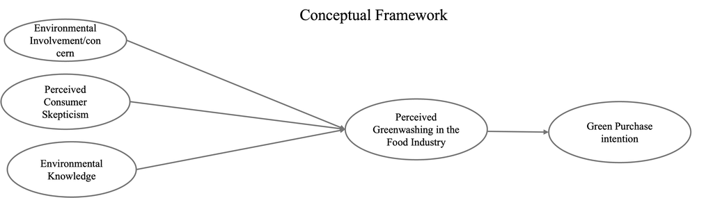

**Warning**

Simulated data

**Warning**

Simulated data

**Warning**

Simulated data

[output not shown]

[output not shown]

[output not shown]

# Footer

**Model fit tresholds and notes**

Less restrictive critical values (Kline, 2010):

- $\chi^2/df<5$
- $CFI > 0.9$
- $TLI > 0.9$
- $SRMR < 0.08$
- $RMSEA < 0.08$

Kline, Rex B. “Promise and pitfalls of structural equation modeling in gifted research.” (2010).

According to [links](https://davidakenny.net/cm/fit.htm) and Satorra-Bentler chi-square statistic (SBchi2) (Satorra & Bentler 2001) - $CFI > 0.95$  
- $RMSEA < 0.06$ - $SRMR < 0.08$

We also reported the significance level associated with the null hypothesis of a population $RMSEA < 0.05$ and the $90\%$ confidence interval bounds for the Robust RMSEA value.

For MLMV estimator, the Robust RMSEA and CFI are not calculated, my functionMyRobustRMSEA.MLMV do the job. REF: Chen, F., Curran, P. J., Bollen, K. A., Kirby, J., & Paxton, P. (2008). An Empirical Evaluation of the Use of Fixed Cutoff Points in RMSEA Test Statistic in Structural Equation Models. Sociological Methods & Research, 36(4), 462–494.

[links](https://doi.org/10.1177/0049124108314720) [links](https://www.tandfonline.com/doi/pdf/10.1080/00273171.2018.1455142?casa_token=mzvORQxTLNEAAAAA:_WT-xLbADPaiUZlfM3B3l7ZGXas6mCzBEzqyGwG1yqNyHqxDsjEnRI9j12HiJjjSsNZbrjnmtYKZ)

Power and minimum sample size for RMSEA links

**Citations**

```r
citations <- lapply(names(sessionInfo()$otherPkgs), citation)
for (pkg in citations) {
  if (!is.null(pkg[[1]]$textVersion) && is.character(pkg[[1]]$textVersion)) {
    cat("------------------------------------------------------------\n")
    cat(pkg[[1]]$textVersion, "\n")
  }
}
```

```
------------------------------------------------------------
Savary, P., Foltête, J.C., Moal, H., Vuidel, G. et Garnier, S. 2020. graph4lg: a package for constructing and analysing graphs for landscape genetics in R. Methods in Ecology and Evolution, 00(1), 1-9. URL https://besjournals.onlinelibrary.wiley.com/doi/abs/10.1111/2041-210X.13530
------------------------------------------------------------
Hlavac, Marek (2022). stargazer: Well-Formatted Regression and Summary Statistics Tables. R package version 5.2.3. https://CRAN.R-project.org/package=stargazer
------------------------------------------------------------
Makowski, D., Lüdecke, D., Patil, I., Thériault, R., Ben-Shachar, M.S., & Wiernik, B.M. (2023). Automated Results Reporting as a Practical Tool to Improve Reproducibility and Methodological Best Practices Adoption. CRAN. Available from https://easystats.github.io/report/ doi: .
------------------------------------------------------------
Jorgensen, T. D., Pornprasertmanit, S., Schoemann, A. M., & Rosseel, Y. (2025). semTools: Useful tools for structural equation modeling. R package version 0.5-7. Retrieved from https://CRAN.R-project.org/package=semTools
------------------------------------------------------------
Yves Rosseel (2012). lavaan: An R Package for Structural Equation Modeling. Journal of Statistical Software, 48(2), 1-36. https://doi.org/10.18637/jss.v048.i02
------------------------------------------------------------
Rademaker, Manuel E. and Schuberth, Florian (2020). cSEM: Composite-Based Structural Equation Modeling. Package version: 0.6.1. URL: https://floschuberth.github.io/cSEM/.
------------------------------------------------------------
Taiyun Wei and Viliam Simko (2024). R package 'corrplot': Visualization of a Correlation Matrix (Version 0.95). Available from https://github.com/taiyun/corrplot
```

**CSS Styling**

```css
.tab-content {
  border-style: none
}
```